# EDA Insurace Dataset 200703

Vijaya Sekhar Gullapalli

7/3/2020

### **1. Insurance DataSet**

The dataset is loaded with strings set as factors. NAs are checked and none are found. The data is inspected using the str and head functions.

```
##      age      sex      bmi children   smoker   region  charges
##        0        0        0        0        0        0        0
```

```
## 'data.frame':    1338 obs. of  7 variables:
##  $ age     : int  19 18 28 33 32 31 46 37 37 60 ...
##  $ sex     : Factor w/ 2 levels "female","male": 1 2 2 2 2 1 1 1 2 1 ...
##  $ bmi     : num  27.9 33.8 33 22.7 28.9 ...
##  $ children: int  0 1 3 0 0 0 1 3 2 0 ...
##  $ smoker  : Factor w/ 2 levels "no","yes": 2 1 1 1 1 1 1 1 1 1 ...
##  $ region  : Factor w/ 4 levels "northeast","northwest",..: 4 3 3 2 2 3 3 2 1 2 ...
##  $ charges : num  16885 1726 4449 21984 3867 ...
```

```
##   age    sex    bmi children smoker    region   charges
## 1  19 female 27.900        0    yes southwest 16884.924
## 2  18   male 33.770        1     no southeast  1725.552
## 3  28   male 33.000        3     no southeast  4449.462
## 4  33   male 22.705        0     no northwest 21984.471
## 5  32   male 28.880        0     no northwest  3866.855
## 6  31 female 25.740        0     no southeast  3756.622
```

### **2. Basic Distribution of Charges**

A quick peek at the histogram shows that majority of the charges lies under 15000, with no significant dependence on sex.

```r
paste("Mean: ",mean(df$charges))
```

```
## [1] "Mean:  13270.4222651413"
```

```r
paste("SD: ",sd(df$charges))
```

```
## [1] "SD:  12110.011236694"
```

```r
quantile(df$charges)
```

```
##        0%       25%       50%       75%      100%
##  1121.874  4740.287  9382.033 16639.913 63770.428
```

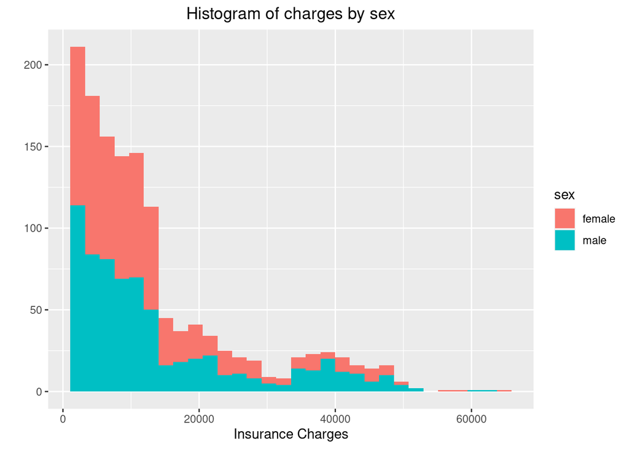

```r
ggplot(df,aes(x=charges)) +
  geom_histogram(aes(fill=sex)) +
  labs(x="Insurance Charges", y="", title = "Histogram of charges by sex")+
  theme(plot.title = element_text(hjust = 0.5))
```

### **3. Total Charges Dependency on Features**

The dependency of total charges on various features in studied using a pair plot, colored by sex. For this plot, the factored features such as smoker and region are converted to numeric. **A strong correlation is observed for being a smoker, followed by age and bmi**. No strong dependence on region or number of children.

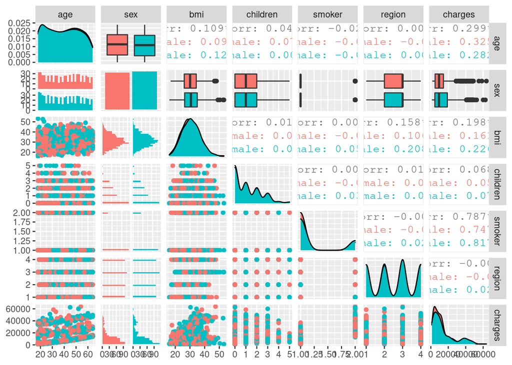

```r
df2=df
df2$smoker<-as.numeric(df2$smoker)
df2$region<-as.numeric(df2$region)
ggpairs(df2,aes(colour=sex))
```

### **4. Regression - Charges dependent on smoker, age and bmi**

An attempt is made to do a multiple regression using the feartures with the strongest correlation, namely, smoker, age and bmi. The R-squared value is not impressive in this approach.

The predicted error for most points is under 50% for most of the cases and is better for smokers. Some insights after the initial try regarding regression are:

1. Perhaps it is better to create seperate models for smokers and non smokers
2. The outliers should have been removed, if they exceed a specific IQR value
3. The data should have been divided into train and test sets. Using all data might result in over fitting.

```r
model=lm(charges~smoker+age+bmi,df2)
summary(model)
```

```
##
## Call:
## lm(formula = charges ~ smoker + age + bmi, data = df2)
##
## Residuals:
##      Min       1Q   Median       3Q      Max
## -12415.4  -2970.9   -980.5   1480.0  28971.8
##
## Coefficients:
##              Estimate Std. Error t value Pr(>|t|)
## (Intercept) -35500.51    1060.50  -33.48   <2e-16 ***
## smoker       23823.68     412.87   57.70   <2e-16 ***
## age            259.55      11.93   21.75   <2e-16 ***
## bmi            322.62      27.49   11.74   <2e-16 ***
## ---
## Signif. codes:  0 '***' 0.001 '**' 0.01 '*' 0.05 '.' 0.1 ' ' 1
##
## Residual standard error: 6092 on 1334 degrees of freedom
## Multiple R-squared:  0.7475, Adjusted R-squared:  0.7469
## F-statistic:  1316 on 3 and 1334 DF,  p-value: < 2.2e-16
```

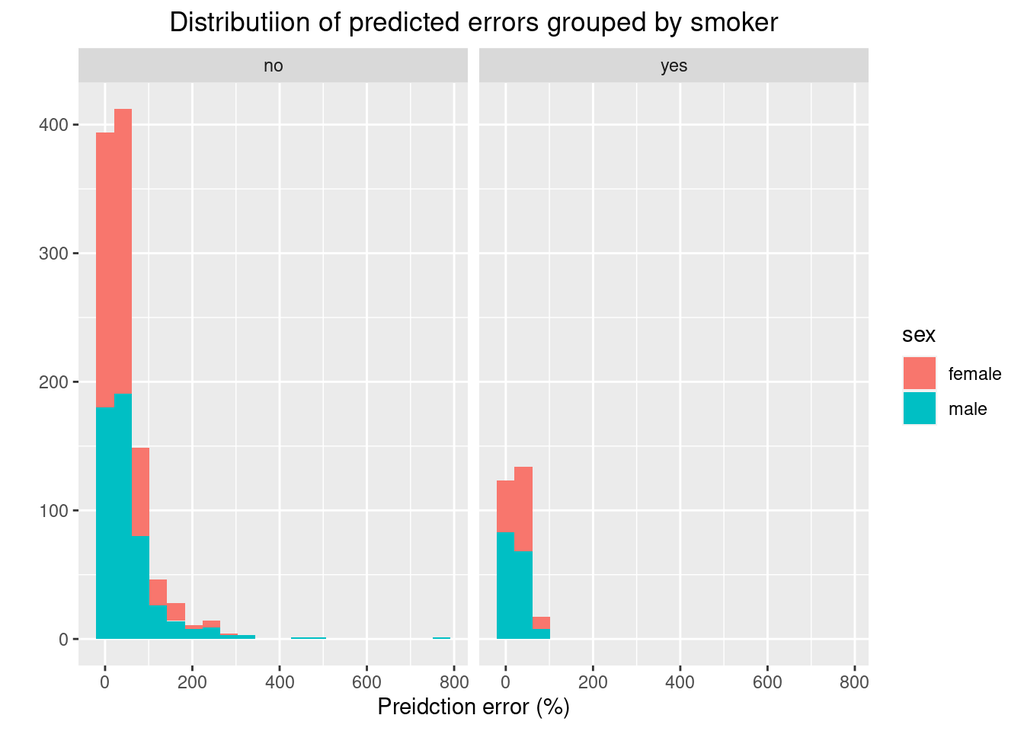

```r
predicted = predict(model,df2)
df3 <- cbind(df,predicted) %>% mutate(error=abs(charges-predicted)/charges*100)
ggplot(df3,aes(x=error, fill=sex)) +
  geom_histogram(bins = 20) +
  labs(x="Preidction error (%)", y="", title = "Distributiion of predicted errors grouped by smoker") +
  facet_wrap(~ smoker)+
  theme(plot.title = element_text(hjust = 0.5))
```